# **Content-based Course Recommender System using Course Similarities**

Estimated time needed: **45** minutes

In one of the previous lab, you have learned and practiced how to calculate the similarity between two courses using Bag of Words (BoW) features. For example, the similarity between course1 `Machine Learning for Everyone` and course2 `Machine Learning for Beginners` are `75%` as shown below.

[figure not shown]

As we mentioned before, the content-based recommender system is highly based on the similarity calculation among items. The similarity or closeness of items is measured based on the similarity in the content or features of those items. The course genres are important features, and in addition to that, the BoW value is another important type of feature to represent course textual content.

In this lab, you will apply the course similarities metric to recommend new courses which are similar to a user's presently enrolled courses.

## Objectives

After completing this lab you will be able to:

- Obtain the similarity between courses from a course similarity matrix
- Use the course similarity matrix to find and recommend new courses which are similar to enrolled courses

## Prepare and setup lab environment

Let's first install and import the required libraries:

```python
!pip install seaborn==0.11.1
```

```
     ━━━━━━━━━━━━━━━━━━━━━━━━━━━━━━━━━━━━━━ 285.0/285.0 kB 31.8 MB/s eta 0:00:00
  Attempting uninstall: seaborn
    Found existing installation: seaborn 0.9.0
    Uninstalling seaborn-0.9.0:
      Successfully uninstalled seaborn-0.9.0
```

```python
import seaborn as sns
import matplotlib.pyplot as plt
import pandas as pd
import numpy as np

%matplotlib inline
```

```python
# also set a random state
rs = 123
```

Next, let's load a pre-made course similarity matrix. If you are interested, you could easily calculate such a similarity matrix by iterating through all possible course pairs and calculating their similarities.

```python
sim_url = "https://cf-courses-data.s3.us.cloud-object-storage.appdomain.cloud/IBM-ML321EN-SkillsNetwork/labs/datasets/sim.csv"
```

```python
sim_df = pd.read_csv(sim_url)
sim_df
```

|  | 0 | 1 | 2 | 3 | 4 | 5 | 6 | 7 | 8 | 9 | ... | 297 | 298 | 299 | 300 | 301 | 302 | 303 | 304 | 305 | 306 |
| --- | --- | --- | --- | --- | --- | --- | --- | --- | --- | --- | --- | --- | --- | --- | --- | --- | --- | --- | --- | --- | --- |
| 0 | 1.000000 | 0.088889 | 0.088475 | 0.065556 | 0.048810 | 0.104685 | 0.065202 | 0.143346 | 0.000000 | 0.024405 | ... | 0.012695 | 0.070225 | 0.058224 | 0.046610 | 0.025850 | 0.033944 | 0.076825 | 0.072898 | 0.039276 | 0.121113 |
| 1 | 0.088889 | 1.000000 | 0.055202 | 0.057264 | 0.012182 | 0.078379 | 0.032545 | 0.119251 | 0.044162 | 0.000000 | ... | 0.180593 | 0.124631 | 0.087187 | 0.093060 | 0.019354 | 0.028239 | 0.063911 | 0.138270 | 0.031367 | 0.076940 |
| 2 | 0.088475 | 0.055202 | 1.000000 | 0.026463 | 0.039406 | 0.000000 | 0.000000 | 0.154303 | 0.000000 | 0.000000 | ... | 0.040996 | 0.037796 | 0.013430 | 0.037630 | 0.000000 | 0.018270 | 0.082698 | 0.133400 | 0.012684 | 0.000000 |
| 3 | 0.065556 | 0.057264 | 0.026463 | 1.000000 | 0.000000 | 0.250490 | 0.390038 | 0.000000 | 0.000000 | 0.000000 | ... | 0.151882 | 0.420084 | 0.427908 | 0.055764 | 0.000000 | 0.094759 | 0.030638 | 0.017443 | 0.018796 | 0.158073 |
| 4 | 0.048810 | 0.012182 | 0.039406 | 0.000000 | 1.000000 | 0.000000 | 0.000000 | 0.085126 | 0.000000 | 0.000000 | ... | 0.000000 | 0.000000 | 0.000000 | 0.096877 | 0.000000 | 0.060474 | 0.030415 | 0.129871 | 0.000000 | 0.000000 |
| ... | ... | ... | ... | ... | ... | ... | ... | ... | ... | ... | ... | ... | ... | ... | ... | ... | ... | ... | ... | ... | ... |
| 302 | 0.033944 | 0.028239 | 0.018270 | 0.094759 | 0.060474 | 0.064851 | 0.053856 | 0.039467 | 0.036539 | 0.060474 | ... | 0.047186 | 0.116008 | 0.137406 | 0.211743 | 0.256220 | 1.000000 | 0.211520 | 0.168595 | 0.129766 | 0.263734 |
| 303 | 0.076825 | 0.063911 | 0.082698 | 0.030638 | 0.030415 | 0.000000 | 0.000000 | 0.119098 | 0.055132 | 0.045622 | ... | 0.177989 | 0.092381 | 0.145126 | 0.527636 | 0.249675 | 0.211520 | 1.000000 | 0.242269 | 0.416067 | 0.178384 |
| 304 | 0.072898 | 0.138270 | 0.133400 | 0.017443 | 0.129871 | 0.009285 | 0.000000 | 0.254274 | 0.094165 | 0.025974 | ... | 0.153128 | 0.105191 | 0.138692 | 0.281108 | 0.132977 | 0.168595 | 0.242269 | 1.000000 | 0.220159 | 0.128902 |
| 305 | 0.039276 | 0.031367 | 0.012684 | 0.018796 | 0.000000 | 0.015008 | 0.024926 | 0.082199 | 0.076102 | 0.055978 | ... | 0.149234 | 0.093962 | 0.162170 | 0.476644 | 0.222350 | 0.129766 | 0.416067 | 0.220159 | 1.000000 | 0.126274 |
| 306 | 0.121113 | 0.076940 | 0.000000 | 0.158073 | 0.000000 | 0.126211 | 0.157219 | 0.000000 | 0.106668 | 0.039231 | ... | 0.142850 | 0.250859 | 0.260731 | 0.099901 | 0.249325 | 0.263734 | 0.178384 | 0.128902 | 0.126274 | 1.000000 |

307 rows × 307 columns

The similarity matrix is a real number, symmetric metric with each element representing the similarity value (ranged 0 to 1) between course index `i` and course index `j`.

We could use `seaborn` to visualize the similarity metric, and since it is symmetric, we can just show the triangular matrix (lower left):

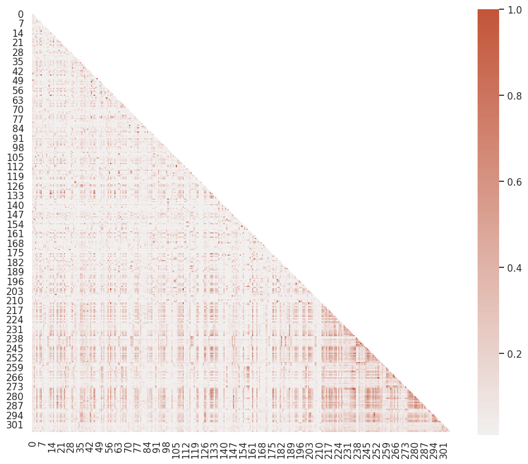

```python
# Configure seaborn
sns.set_theme(style="white")
mask = np.triu(np.ones_like(sim_df, dtype=bool))
_, ax = plt.subplots(figsize=(11, 9))
cmap = sns.diverging_palette(230, 20, as_cmap=True)
# Plot a similarity heat map
sns.heatmap(sim_df, mask=mask, cmap=cmap, vmin=0.01, vmax=1, center=0,
            square=True)
```

As we can see from the heatmap; there are many hot spots, which means many courses are similar to each other. Such patterns suggest that it is possible to build a recommender system based on course similarities.

Let's take a look at a quick example:

```python
# Let's first load the course content and BoW dataset
course_url = "https://cf-courses-data.s3.us.cloud-object-storage.appdomain.cloud/IBM-ML321EN-SkillsNetwork/labs/datasets/course_processed.csv"
course_df = pd.read_csv(course_url)
bow_url = "https://cf-courses-data.s3.us.cloud-object-storage.appdomain.cloud/IBM-ML321EN-SkillsNetwork/labs/datasets/courses_bows.csv"
bow_df = pd.read_csv(bow_url)
```

```python
course_df.head()
```

|  | COURSE_ID | TITLE | DESCRIPTION |
| --- | --- | --- | --- |
| 0 | ML0201EN | robots are coming build iot apps with watson ... | have fun with iot and learn along the way if ... |
| 1 | ML0122EN | accelerating deep learning with gpu | training complex deep learning models with lar... |
| 2 | GPXX0ZG0EN | consuming restful services using the reactive ... | learn how to use a reactive jax rs client to a... |
| 3 | RP0105EN | analyzing big data in r using apache spark | apache spark is a popular cluster computing fr... |
| 4 | GPXX0Z2PEN | containerizing packaging and running a sprin... | learn how to containerize package and run a ... |

```python
bow_df.head()
```

|  | doc_index | doc_id | token | bow |
| --- | --- | --- | --- | --- |
| 0 | 0 | ML0201EN | ai | 2 |
| 1 | 0 | ML0201EN | apps | 2 |
| 2 | 0 | ML0201EN | build | 2 |
| 3 | 0 | ML0201EN | cloud | 1 |
| 4 | 0 | ML0201EN | coming | 1 |

```python
bow_df.groupby(['doc_index', 'doc_id']).max().reset_index(drop=True) #groupby sets index as
#'doc_index', 'doc_id' for the calculation of max token bow per article, then reset_index
#removes these so that docs are represented by their plain index
```

|  | token | bow |
| --- | --- | --- |
| 0 | way | 4 |
| 1 | videos | 7 |
| 2 | using | 2 |
| 3 | using | 4 |
| 4 | spring | 2 |
| ... | ... | ... |
| 302 | web | 5 |
| 303 | write | 6 |
| 304 | working | 13 |
| 305 | world | 8 |
| 306 | work | 5 |

307 rows × 2 columns

```python
#bow_df.groupby(['doc_index', 'doc_id']).max().reset_index(drop=True)[['doc_id']].get_level_values(1).tolist()['doc_id']
#???????
```

First, we want to mention that the matrix indices are course indices (such as `0, 1, 2, 3`). Very often we need to query the actual course ids (such as `ML0151EN` and `ML0101ENv3`) based on course indices and vice versa. We can save the course id's and indices into two dictionaries for late queries:

Then, based on the `doc_index` and `doc_id` columns, we create an index to id mapping and another id to index mapping in two Python dictionaries:

```python
# Create course id to index and index to id mappings
def get_doc_dicts(bow_df):
    grouped_df = bow_df.groupby(['doc_index', 'doc_id']).max().reset_index(drop=False)
    idx_id_dict = grouped_df[['doc_id']].to_dict()['doc_id']
    id_idx_dict = {v: k for k, v in idx_id_dict.items()}
    del grouped_df
    return idx_id_dict, id_idx_dict
```

Now suppose we have two example courses:

```python
course1 = course_df[course_df['COURSE_ID'] == "ML0151EN"]
course1
```

|  | COURSE_ID | TITLE | DESCRIPTION |
| --- | --- | --- | --- |
| 200 | ML0151EN | machine learning with r | this machine learning with r course dives into... |

```python
course2 = course_df[course_df['COURSE_ID'] == "ML0101ENv3"]
course2
```

|  | COURSE_ID | TITLE | DESCRIPTION |
| --- | --- | --- | --- |
| 158 | ML0101ENv3 | machine learning with python | machine learning can be an incredibly benefici... |

From their titles we can see they are all about machine learning. As such, they should be very similar to each other. Let's try to find their similarity in the similarity matrix.

With their course ids, we can use the `id_idx_dict` dictionary to query their row and column index on the similarity matrix:

```python
idx_id_dict, id_idx_dict = get_doc_dicts(bow_df)
idx1 = id_idx_dict["ML0151EN"]
idx2 = id_idx_dict["ML0101ENv3"]
print(f"Course 1's index is {idx1} and Course 2's index is {idx2}")
```

```
Course 1's index is 200 and Course 2's index is 158
```

```python
#similarly you could find course code from index
idx_id_dict[69]
```

```
'GPXX0742EN'
```

```python
for key, value in list(idx_id_dict.items())[:4]:   #preview idx_id_dict dictionary
    print(f'{key}: {value}')  # idx is matrix index. id is doc index.
```

```
0: ML0201EN
1: ML0122EN
2: GPXX0ZG0EN
3: RP0105EN
```

```python
for key, value in list(id_idx_dict.items())[:4]:   #preview id_idx_dict dictionary
    print(f'{key}: {value}')
```

```
ML0201EN: 0
ML0122EN: 1
GPXX0ZG0EN: 2
RP0105EN: 3
```

Then we can locate their similarity value in row 200 and col 158, `sim_matrix[200][158]`:

```python
sim_matrix = sim_df.to_numpy()
```

```python
sim = sim_matrix[idx1][idx2]
sim
```

```
0.6626221399549089
```

It's about 66% meaning these two courses are quite similar to each other.

### TASK: Find courses which are similar enough to your enrolled courses.

Now you know how to easily use the pre-computed similarity matrix to query the similarity between any two courses. Do you want to make some course recommendations for yourself?

Let's assume you are an end-user of the online course platform and already audited or completed some courses previously. Next, you expect the system would recommend similar courses based on your enrollments history.

From the full course list, choose any courses that may interest you, such as those machine learning related courses:

```python
pd.set_option('display.max_rows', None)
pd.set_option('max_colwidth', None)
course_df[['COURSE_ID', 'TITLE']]
```

|  | COURSE_ID | TITLE |
| --- | --- | --- |
| 0 | ML0201EN | robots are coming build iot apps with watson swift and node red |
| 1 | ML0122EN | accelerating deep learning with gpu |
| 2 | GPXX0ZG0EN | consuming restful services using the reactive jax rs client |
| 3 | RP0105EN | analyzing big data in r using apache spark |
| 4 | GPXX0Z2PEN | containerizing packaging and running a spring boot application |
| 5 | CNSC02EN | cloud native security conference data security |
| 6 | DX0106EN | data science bootcamp with r for university proffesors |
| 7 | GPXX0FTCEN | learn how to use docker containers for iterative development |
| 8 | RAVSCTEST1 | scorm test 1 |
| 9 | GPXX06RFEN | create your first mongodb database |
| 10 | GPXX0SDXEN | testing microservices with the arquillian managed container |
| 11 | CC0271EN | cloud pak for integration essentials |
| 12 | WA0103EN | watson analytics for social media |
| 13 | DX0108EN | data science bootcamp with python for university professors advance |
| 14 | GPXX0PICEN | create a cryptocurrency trading algorithm in python |
| 15 | DAI101EN | data ai essentials |
| 16 | GPXX0W7KEN | securing java microservices with eclipse microprofile json web token microprofile jwt |
| 17 | GPXX0QR3EN | enabling distributed tracing in microservices with zipkin |
| 18 | BD0145EN | sql access for hadoop |
| 19 | HCC105EN | hybrid cloud conference ai pipelines lab |
| 20 | DE0205EN | dataops methodology |
| 21 | DS0132EN | data ai jumpstart your journey |
| 22 | OS0101EN | introduction to open source |
| 23 | DS0201EN | end to end data science on cloudpak for data |
| 24 | BENTEST4 | ai for everyone master the basics |
| 25 | CC0210EN | serverless computing using cloud functions developer i |
| 26 | PA0103EN | predicting customer satisfaction |
| 27 | HCC104EN | hybrid cloud conference serverless lab |
| 28 | GPXX0A1YEN | validating constraints for javabeans in java microservices |
| 29 | TMP0105EN | getting started with the data apache spark makers build |

[output cut: 277 more lines]

```python
# Reset pandas settings
pd.reset_option('display.max_rows')
pd.reset_option('max_colwidth')
```

*TODO: Browse the course list and choose your interested courses*

```python
enrolled_course_ids = ['excourse26', 'excourse45', 'excourse73', 'excourse79'] # add your interested coures id to the list
```

```python
enrolled_courses = course_df[course_df['COURSE_ID'].isin(enrolled_course_ids)]
enrolled_courses
```

|  | COURSE_ID | TITLE | DESCRIPTION |
| --- | --- | --- | --- |
| 239 | excourse26 | cloud computing foundations | welcome to the first course in the building cl... |
| 258 | excourse45 | docker basics | the docker basics course will introduce you at... |
| 286 | excourse73 | analyzing big data with sql | in this course you ll get an in depth look at... |
| 292 | excourse79 | natural language processing with probabilistic... | in course 2 of the natural language processing... |

Given the full course list, we can find those unselected courses:

```python
all_courses = set(course_df['COURSE_ID'])
```

```python
unselected_course_ids = all_courses.difference(enrolled_course_ids)
unselected_course_ids
```

Now, you can iterate each unselect course and check if it is similar enough to any of your selected courses. If the similarity is larger than a threshold such as 0.5 or 0.6, then add it to your course recommendation list:

*TODO: Complete the following method to recommend courses which are similar to your enrolled courses*

```python
def generate_recommendations_for_one_user(enrolled_course_ids, unselected_course_ids, id_idx_dict, sim_matrix):
    # Create a dictionary to store your recommendation results
    res = {}
    threshold = 0.5
    for enrolled_course in enrolled_course_ids:  #enrolled= chosen earlier
        for unselect_course in unselected_course_ids:
            if enrolled_course in id_idx_dict and unselect_course in id_idx_dict:

                # sim = 0
                # Find the two indices for each enrolled_course and unselect_course, based on their two ids
                # Calculate the similarity between an enrolled_course and an unselect_course
                # e.g., Course ML0151EN's index is 200 and Course ML0101ENv3's index is 158

                sim = sim_matrix[id_idx_dict[enrolled_course]][id_idx_dict[unselect_course]]

                # Find the similarity value from the sim_matrix
                # sim = sim_matrix[200][158]

                if sim > threshold:
                    if unselect_course not in res:
                        res[unselect_course] = sim
                    else:
                        if sim >= res[unselect_course]:
                            res[unselect_course] = sim

    # Sort the results by similarity
    res = {k: v for k, v in sorted(res.items(), key=lambda item: item[1], reverse=True)}
    return res
```

**Click here for Hints**

You can find the indices of the courses by using `id_idx_dict` dictionary, for example `id_idx_dict[enrolled_course]`. Then use `sim_matrix` to find the similarity of the courses as was shown earlier in the lab.

```python
ok = generate_recommendations_for_one_user(enrolled_course_ids, unselected_course_ids, id_idx_dict, sim_matrix)
```

```python
ok
```

```
{'excourse43': 0.7427111973240749,
 'excourse24': 0.5405584979039622,
 'excourse28': 0.5184177841087043,
 'excourse30': 0.509019618079903}
```

```python
courses=[]
sims=[]
for course, sim in list(ok.items())[:4]:   #preview idx_id_dict dictionary
    courses.append(course)
    sims.append(sim)

print(courses)
```

```
['excourse43', 'excourse24', 'excourse28', 'excourse30']
```

The completed `generate_recommendations_user(...)` may ouput a dictionary like this:

{'ML0151EN': 0.6626221399549089, 'excourse47': 0.6347547807096177, 'excourse46': 0.6120541193300345}

### TASK: Generate course recommendations based on course similarities for all test uesrs

In the previous task, you made some recommendations for yourself. Next, let's try to make recommendations for all the test users in the test dataset.

```python
test_users_url = "https://cf-courses-data.s3.us.cloud-object-storage.appdomain.cloud/IBM-ML321EN-SkillsNetwork/labs/datasets/rs_content_test.csv"
test_users_df = pd.read_csv(test_users_url)
```

Let's look at how many test users we have in the dataset.

```python
test_users = test_users_df.groupby(['user']).max().reset_index(drop=False)
test_user_ids = test_users['user'].to_list()
print(f"Total numbers of test users {len(test_user_ids)}")
```

```
Total numbers of test users 1000
```

*TODO: Complete the `generate_recommendations_for_all()` method to generate recommendations for all users. You may implement the task with different solutions*

```python
test_users.groupby(['user']).head()
```

|  | user | item | rating |
| --- | --- | --- | --- |
| 0 | 37465 | SC0101EN | 3.0 |
| 1 | 50348 | RP0101EN | 3.0 |
| 2 | 52091 | ML0122ENv1 | 3.0 |
| 3 | 70434 | TMP0105EN | 3.0 |
| 4 | 85625 | TA0105 | 3.0 |
| ... | ... | ... | ... |
| 995 | 2061096 | SC0101EN | 3.0 |
| 996 | 2074313 | PY0101EN | 3.0 |
| 997 | 2074462 | ST0101EN | 3.0 |
| 998 | 2082818 | SECM03EN | 3.0 |
| 999 | 2087663 | SECM03EN | 3.0 |

1000 rows × 3 columns

```python
test_users_df.groupby(['user']).max().reset_index(drop=False)['user'].to_list()[:4]
```

```
[37465, 50348, 52091, 70434]
```

```python
course_df.head()
```

|  | COURSE_ID | TITLE | DESCRIPTION |
| --- | --- | --- | --- |
| 0 | ML0201EN | robots are coming build iot apps with watson ... | have fun with iot and learn along the way if ... |
| 1 | ML0122EN | accelerating deep learning with gpu | training complex deep learning models with lar... |
| 2 | GPXX0ZG0EN | consuming restful services using the reactive ... | learn how to use a reactive jax rs client to a... |
| 3 | RP0105EN | analyzing big data in r using apache spark | apache spark is a popular cluster computing fr... |
| 4 | GPXX0Z2PEN | containerizing packaging and running a sprin... | learn how to containerize package and run a ... |

```python
bow_df.head()
```

|  | doc_index | doc_id | token | bow |
| --- | --- | --- | --- | --- |
| 0 | 0 | ML0201EN | ai | 2 |
| 1 | 0 | ML0201EN | apps | 2 |
| 2 | 0 | ML0201EN | build | 2 |
| 3 | 0 | ML0201EN | cloud | 1 |
| 4 | 0 | ML0201EN | coming | 1 |

```python
test_users_df.head()
```

|  | user | item | rating |
| --- | --- | --- | --- |
| 0 | 1502801 | RP0105EN | 3.0 |
| 1 | 1609720 | CNSC02EN | 2.0 |
| 2 | 1347188 | CO0301EN | 3.0 |
| 3 | 755067 | ML0103EN | 3.0 |
| 4 | 538595 | BD0115EN | 3.0 |

```python
filtered_df = test_users_df[test_users_df['rating'] != 2.0]
```

```python
items_df = filtered_df.groupby('user').agg({'item': lambda x: x.tolist()})
items_df = items_df.reset_index()
items_df.columns = ['user','items']
items_df
```

|  | user | items |
| --- | --- | --- |
| 0 | 37465 | [DS0101EN, BD0111EN, BD0101EN, BD0211EN, SC010... |
| 1 | 50348 | [PY0101EN, CB0105ENv1, CC0103EN, RP0101EN, DV0... |
| 2 | 52091 | [ML0101ENv3, ML0115EN, CC0201EN, DA0101EN, CC0... |
| 3 | 70434 | [BD0141EN, BD0111EN, BD0131EN, BD0145EN, BD013... |
| 4 | 85625 | [BD0133EN, PA0101EN, BD0141EN, BD0111EN, BD011... |
| ... | ... | ... |
| 994 | 2061096 | [BD0211EN, BD0141EN, CC0201EN, DB0101EN, BD011... |
| 995 | 2074313 | [PY0101EN, DS0101EN, BD0111EN, DV0101EN, BD021... |
| 996 | 2074462 | [CC0103EN, EE0101EN, AI0111EN, BC0201EN, PY010... |
| 997 | 2082818 | [ML0111EN, ML0103EN, BD0123EN, DV0101EN, SC010... |
| 998 | 2087663 | [BC0101EN, ML0122ENv3, BD0121EN, ML0151EN, BC0... |

999 rows × 2 columns

```python
items_df[items_df['user']==52091]['items'].tolist()[0][0]
```

```
'ML0101ENv3'
```

```python
# test_users.groupby(['user']).head()
# result_df = test_users.groupby('user')['item'].apply(', '.join).reset_index()
# result_df

# filtered_df = test_users_df[test_users_df['rating'] != 2.0]
# result_df = filtered_df.groupby('user')['item'].apply(', '.join).reset_index()
# result_df

result_df = filtered_df[filtered_df['rating'] != 2.0].groupby('user')['item'].unique()#reset_index()
result_df
```

```python
test_users_df[test_users_df['rating']==3]['item'].values.tolist() #.reset_index()
```

```python
test_users.groupby(['user'])['item'].unique().tolist()
# test_users.drop(columns=['rating'], inplace=True)
# test_users
```

```python
result_df = test_users.groupby('user').agg({'item': ', '.join}).reset_index()
result_df
```

```python
test_users.user.unique().tolist()
```

```python
test_users[test_users['user']==85625]['item']
```

```
4    TA0105
Name: item, dtype: object
```

```python
ok = test_users[test_users['user']==user_id]
```

```python
enrolled_course_ids=[]
for user_id in test_users.user.unique().tolist():
    items = test_users[test_users['user']==user_id].groupby(['user'])['item'].head().values.tolist()
    enrolled_course_ids.append((user_id,items))
```

```python
test_users[test_users['user']==85625].groupby(['user'])['item'].head(99999999).values.tolist()
```

```
['TA0105']
```

```python
# WRITE YOUR CODE HERE
def generate_recommendations_for_all():
    users = []
    courses = []
    sim_scores = []
    # Test user dataframe
    # Course similarity matrix
    sim_df = pd.read_csv(sim_url)
    # Course content dataframe
    course_df = pd.read_csv(course_url)
    # Course BoW features
    bow_df = pd.read_csv(bow_url)

    # test_users = test_users_df.groupby(['user']).max().reset_index(drop=False)  #max gives 3(compl) if present. min=2(didnt finish course). reset_index changes index from user to standard index
    # test_user_ids = test_users['user'].to_list()

    test_user_ids = np.sort(test_users_df['user'].unique()).tolist()

    for user_id in test_user_ids:
        enrolled_course_ids = []
        items = items_df[items_df['user']==user_id]['items'].tolist()
        for i in range(len(items)):
            enrolled_course_ids.append(items[0][i])


         # enrolled_course_ids = [item for sublist in items for item in sublist]

        # enrolled_course_ids = set(enrolled_course_ids)
        # all_courses = set(course_df['COURSE_ID'])

        unselected_course_ids = all_courses.difference(enrolled_course_ids)
        res = generate_recommendations_for_one_user(enrolled_course_ids, unselected_course_ids, id_idx_dict, sim_matrix)

#         # Ensure 'COURSE_ID' and 'SCORE' keys are present in the result
#         if 'COURSE_ID' in res and 'SCORE' in res:
#             courses.append(res['COURSE_ID'])
#             sim_scores.append(res['SCORE'])
#         else:
#             # Handle the case where the keys are not present in the result
#             print(f"Warning: 'COURSE_ID' or 'SCORE' keys not found in the result for user {user_id}")


#         print(unselected_course_ids)






        # res = generate_recommendations_for_one_user(enrolled_course_ids, unselected_course_ids, id_idx_dict, sim_matrix)
        # For each user, call generate_recommendations_for_one_user() to generate the recommendation results
        # Save the result to courses, sim_scores list
        for course, sim in list(res.items()):
            # while user_id not in users:

            # print(users)
            # print(course)
            # print(sim)
            users.append(user_id)
            courses.append(course)
            sim_scores.append(sim)
        pass

    return users, courses, sim_scores
```

**Click here for Hints**

Note that you can use `generate_recommendations_for_one_user` function to find the list of recommended courses for each user. Find the `enrolled_course_ids` list by simply finding them in the `test_users` list by running `test_users[test_users['user']==user_id]['item']` and to find the unselected courses list you can apply `all_courses.difference()` with `enrolled_course_ids` as it's parameter (as done earlier in the lab). (Keep the last 2 parameters of `generate_recommendations_for_one_user` the same)

After you completed the `generate_recommendations_for_all()` function, you can call it to save the results into a dataframe:

```python
res_dict = {}
users, courses, sim_scores = generate_recommendations_for_all()
res_dict['USER'] = users
res_dict['COURSE_ID'] = courses
res_dict['SCORE'] = sim_scores

# print(len(res_dict['USER']))
# print(len(res_dict['COURSE_ID']))
# print(len(res_dict['SCORE']))

res_df = pd.DataFrame(res_dict, columns=['USER', 'COURSE_ID', 'SCORE'])
res_df.head(20)
```

|  | USER | COURSE_ID | SCORE |
| --- | --- | --- | --- |
| 0 | 37465 | DS0110EN | 0.732941 |
| 1 | 37465 | excourse63 | 0.694563 |
| 2 | 37465 | excourse65 | 0.638641 |
| 3 | 37465 | TMP0106 | 0.597925 |
| 4 | 37465 | excourse32 | 0.597780 |
| 5 | 37465 | excourse04 | 0.569979 |
| 6 | 37465 | excourse23 | 0.569039 |
| 7 | 37465 | excourse36 | 0.569039 |
| 8 | 37465 | DS0201EN | 0.567734 |
| 9 | 37465 | TMP107 | 0.566947 |
| 10 | 37465 | DS0107 | 0.566947 |
| 11 | 37465 | excourse68 | 0.547459 |
| 12 | 37465 | DX0106EN | 0.543943 |
| 13 | 37465 | excourse64 | 0.541313 |
| 14 | 37465 | excourse33 | 0.539060 |
| 15 | 37465 | excourse67 | 0.531523 |
| 16 | 37465 | excourse09 | 0.509427 |
| 17 | 50348 | excourse62 | 0.647502 |
| 18 | 50348 | excourse22 | 0.647502 |
| 19 | 50348 | TMP107 | 0.546608 |

```python
len(res_df[res_df.USER==37465].COURSE_ID.tolist())
```

```
17
```

```python
np.mean([len(res_df[res_df.USER==user_id].COURSE_ID.tolist()) for user_id in test_user_ids])
```

```
4.137
```

```python
res_df.COURSE_ID.value_counts().sort_values(ascending=False).head(10)
```

```
excourse68    226
excourse32    211
excourse67    186
DS0110EN      170
excourse23    169
excourse36    169
excourse63    128
TMP107        127
excourse65    121
excourse09    121
Name: COURSE_ID, dtype: int64
```

Similar to the previous user profile and course genre lab, with the recommendations generated for each user, you need to write some extra analytic code to answer the following questions:

- On average, how many new/unseen courses have been recommended to each user?
- What are the most frequently recommended courses? Return the top-10 commonly recommended courses across all users?

For example, suppose we have only 3 test users, each user receives the following recommendations:

- User1: ['course1', 'course2']
- User2: ['course3', 'course4']
- User3: ['course3', 'course4', 'course5']

Then, the average recommended courses per user is $(2 + 2 + 3) / 3 = 2.33$. The top-2 recommended courses are: `course3`: 2 times, and `course4`: 2 times.

Ideally, we should limit the maximum course recommendations for each user to be less than 20 courses per user.

## Authors

Yan Luo

## Change Log

| Date (YYYY-MM-DD) | Version | Changed By | Change Description |
| --- | --- | --- | --- |
| 2021-10-25 | 1.0 | Yan | Created the initial version |

Copyright © 2021 IBM Corporation. All rights reserved.